# ECON6027_8a

Dr. Liu

# GEOSPATIAL ANALYSIS

Load the required packages. Note that the “dismo” package loaded here is in need of an updated to work with the lates spatial object styles. Alternative more up to date packages exists, however, are more generic and less compatible with spatial objects.

```r
library(gstat)
library(dismo); library(sf); library(tmap)
```

## Dataset

Airborne counts of Fulmaris glacialis during the Aug/Sept 1998 and 1999 flights on the Dutch (Netherlands) part of the North Sea

```r
data(fulmar); head(fulmar)
```

```
##   year        x       y depth    coast fulmar
## 1 1998 614192.3 5875490     6 3.445307      0
## 4 1998 613150.8 5872947     6 3.445307      0
## 5 1998 619644.7 5888800     9 3.042531      0
## 6 1998 608858.6 5839623    16 3.845921      0
## 7 1998 556583.0 5738519     1 2.701462      0
## 8 1998 553423.7 5735916     3 1.807041      0
```

We will create a Voronoi tessellation for the spatial points df to provide NN interpolations: see https://en.wikipedia.org/wiki/Voronoi_diagram for more details. Convert to sf and assign CRS UTM Zone 31N

```r
fulmar_sf = st_as_sf(fulmar, coords=c("x","y"), crs=32631) # UTM Zone 31N
```

Extract the data for year 1999 and plot.

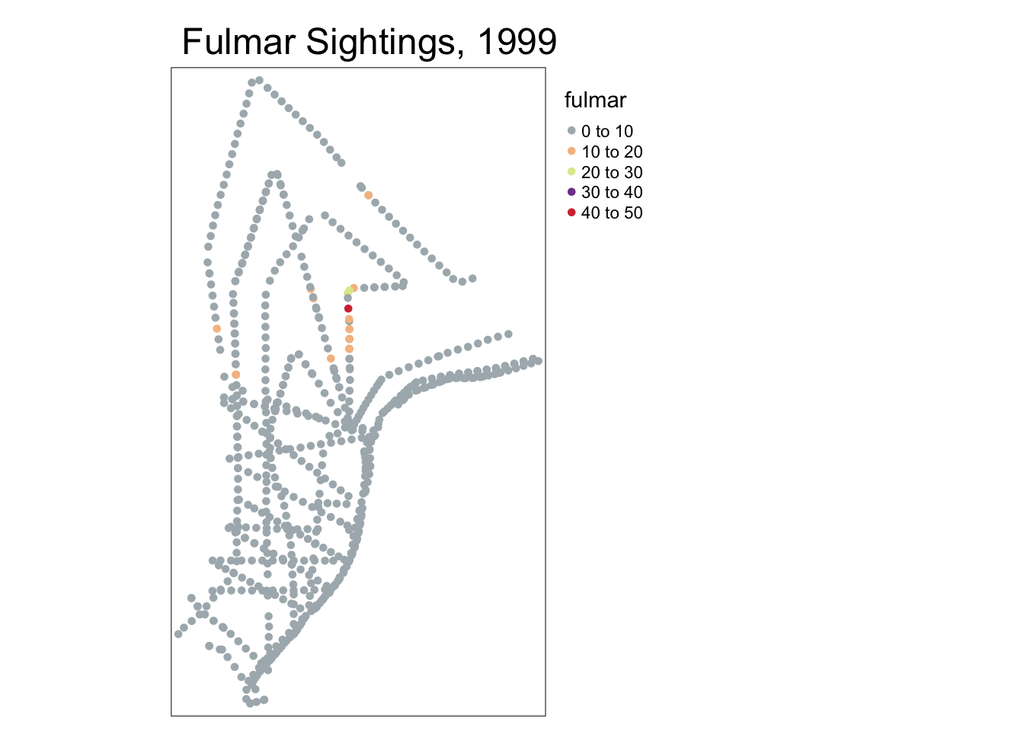

```r
fulmar99 = fulmar_sf[fulmar$year==1999, ]
tm_shape(fulmar99) +
  tm_symbols(col="fulmar", palette="Accent", shape=20, size=0.2) +
  tm_layout(legend.outside="T", main.title = "Fulmar Sightings, 1999")
```

## Nearest Neighbour Interpolation

At the moment, dismo only works on sp objects. Hence, we convert the sf to sp which can be done easily as there is smooth transition between the two.

```r
fulmar99_sp = as(fulmar99, "Spatial") # voronoi function needs "SpatialPoints"
```

Create Voronoi Tesselation:

```r
voro = voronoi(fulmar99_sp, ext=st_bbox(fulmar99))
class(voro) # output is a sp polygon object
```

```
## [1] "SpatialPolygonsDataFrame"
## attr(,"package")
## [1] "sp"
```

Visualise the Voronoi Tesselation:

```r
(voro_sf = st_as_sf(voro, crs=32631))
```

```
## Simple feature collection with 729 features and 4 fields
## Geometry type: POLYGON
## Dimension:     XY
## Bounding box:  xmin: 476209.6 ymin: 5695049 xmax: 735071.7 ymax: 6143369
## Projected CRS: +proj=utm +zone=31 +datum=WGS84 +units=m +no_defs
## First 10 features:
##    year depth     coast   fulmar                       geometry
## 1  1999    39  74.32973  0.00000 POLYGON ((656993.9 5988304,...
## 2  1999    39  66.93047  0.00000 POLYGON ((621770.4 5972015,...
## 3  1999    40  87.58816  6.83660 POLYGON ((587962.6 5975436,...
## 4  1999    33  66.16789  0.00000 POLYGON ((519371.2 5800328,...
## 5  1999    26  51.32900  0.00000 POLYGON ((593794.3 5935591,...
## 6  1999    21  33.62153  0.00000 POLYGON ((512644.7 5738338,...
## 7  1999    44  85.68657 28.42134 POLYGON ((585502.3 5998381,...
## 8  1999    36 140.23980  0.00000 POLYGON ((527315.8 5992129,...
## 9  1999    31  63.64503  0.00000 POLYGON ((486951.4 5739733,...
## 10 1999    25  41.07539  0.00000 POLYGON ((596477.3 5923979,...
```

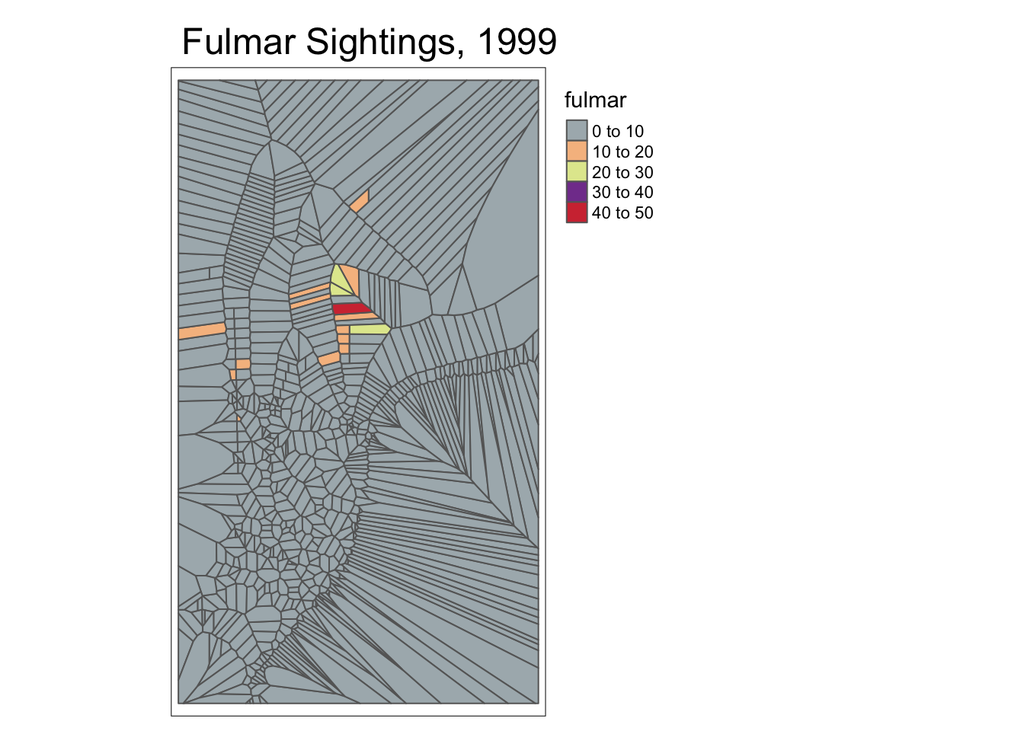

```r
tm_shape(voro_sf) +
  tm_polygons(col="fulmar", palette="Accent") +
  tm_layout(legend.outside="T", main.title = "Fulmar Sightings, 1999")
```

### Other ways of creating Voronoi maps in R

In the chunks above, we have used the “dismo” package. The advantage of the dismo package is that it accepts “sp” objects and the output is also a “sp” object. However, an update is in order to admit “sf” objects. Other methods include:

- “[deldir](https://r-charts.com/part-whole/voronoi-diagram/)” function in the package “deldir”. This is a very old package (1995/96) that has withstood the test of time! The input needs to be in coordinates and the output is a list object of class “deldir”. I did not use this here to avoid the need for additional manipulation to convert a “deldir” object to “sf”.
- “[voronoi](https://rdrr.io/cran/terra/man/voronoi.html)” function in the package “terra”. The package requires the spatial object to belong to the raster class “SpatVector”.
- Plot with “ggplot2” using the partner package “[ggvoronoi](https://r-charts.com/part-whole/ggvoronoi/)”. If you are familiar with the ggplot grammar, you are welcome to try the functionality in this package.

## Inverse Distance Weighting interpolation

Inverse distance weighting (IWD) is a deterministic interpolation technique that estimates the values of the unsampled points according to the values at nearby locations weighted only by distance. IWD assumes that the relationship between nearby location and interpolation location is stronger compared to locations that are farther. Thus, it has the advantage of not relying only on the nearest observation unlike NN interpolation. IWD provides an easier way to predict values of continuous variables, however it is not sensitive to areas of peaks or pits and thus lead to undesirable results.

- idw function in “gstat” package works with sp/sf objects (a CRS must be set).
- idw function needs a set of unsampled locations to be interpolated.

```r
data(ncp.grid) # if no unsampled set is present, you need to create one based on the region polygon.
```

Inspect the set of unsampled points.

```r
class(ncp.grid) # not a spatial object
```

```
## [1] "data.frame"
```

```r
(ncp.gridsf = st_as_sf(ncp.grid, coords=c("x","y"), crs=32631))
```

```
## Simple feature collection with 2297 features and 3 fields
## Geometry type: POINT
## Dimension:     XY
## Bounding box:  xmin: 466500 ymin: 5699000 xmax: 736500 ymax: 6129000
## Projected CRS: WGS 84 / UTM zone 31N
## First 10 features:
##    depth coast area               geometry
## 1     30   248    1 POINT (511500 6129000)
## 2     30   247    1 POINT (516500 6129000)
## 3     30   244    1 POINT (521500 6129000)
## 4     30   242    1 POINT (526500 6129000)
## 5     30   239    1 POINT (531500 6129000)
## 6     30   237    1 POINT (536500 6129000)
## 7     30   234    1 POINT (541500 6129000)
## 8     30   232    1 POINT (546500 6129000)
## 9     30   230    1 POINT (551500 6129000)
## 10    31   228    1 POINT (556500 6129000)
```

IDW estimate:

```r
(fulmar_idw1 = gstat::idw(formula=fulmar~1, locations=fulmar99, newdata=ncp.gridsf, idp = 1)) # inverse
```

```
## [inverse distance weighted interpolation]
```

```
## Simple feature collection with 2297 features and 2 fields
## Geometry type: POINT
## Dimension:     XY
## Bounding box:  xmin: 466500 ymin: 5699000 xmax: 736500 ymax: 6129000
## Projected CRS: WGS 84 / UTM zone 31N
## First 10 features:
##    var1.pred var1.var               geometry
## 1   1.551593       NA POINT (511500 6129000)
## 2   1.530795       NA POINT (516500 6129000)
## 3   1.480545       NA POINT (521500 6129000)
## 4   1.436883       NA POINT (526500 6129000)
## 5   1.554843       NA POINT (531500 6129000)
## 6   1.629213       NA POINT (536500 6129000)
## 7   1.657564       NA POINT (541500 6129000)
## 8   1.672028       NA POINT (546500 6129000)
## 9   1.739322       NA POINT (551500 6129000)
## 10  1.841795       NA POINT (556500 6129000)
```

```r
(fulmar_idw2 = gstat::idw(formula=fulmar~1, locations=fulmar99, newdata=ncp.gridsf, idp = 2)) # inverse square
```

```
## [inverse distance weighted interpolation]
```

```
## Simple feature collection with 2297 features and 2 fields
## Geometry type: POINT
## Dimension:     XY
## Bounding box:  xmin: 466500 ymin: 5699000 xmax: 736500 ymax: 6129000
## Projected CRS: WGS 84 / UTM zone 31N
## First 10 features:
##    var1.pred var1.var               geometry
## 1  1.3392497       NA POINT (511500 6129000)
## 2  1.0882239       NA POINT (516500 6129000)
## 3  0.6618765       NA POINT (521500 6129000)
## 4  0.4245152       NA POINT (526500 6129000)
## 5  1.0926721       NA POINT (531500 6129000)
## 6  1.6610271       NA POINT (536500 6129000)
## 7  1.6246147       NA POINT (541500 6129000)
## 8  1.4646454       NA POINT (546500 6129000)
## 9  1.6321421       NA POINT (551500 6129000)
## 10 3.0618283       NA POINT (556500 6129000)
```

Basic plots of var1.pred (variable 1: prediction)

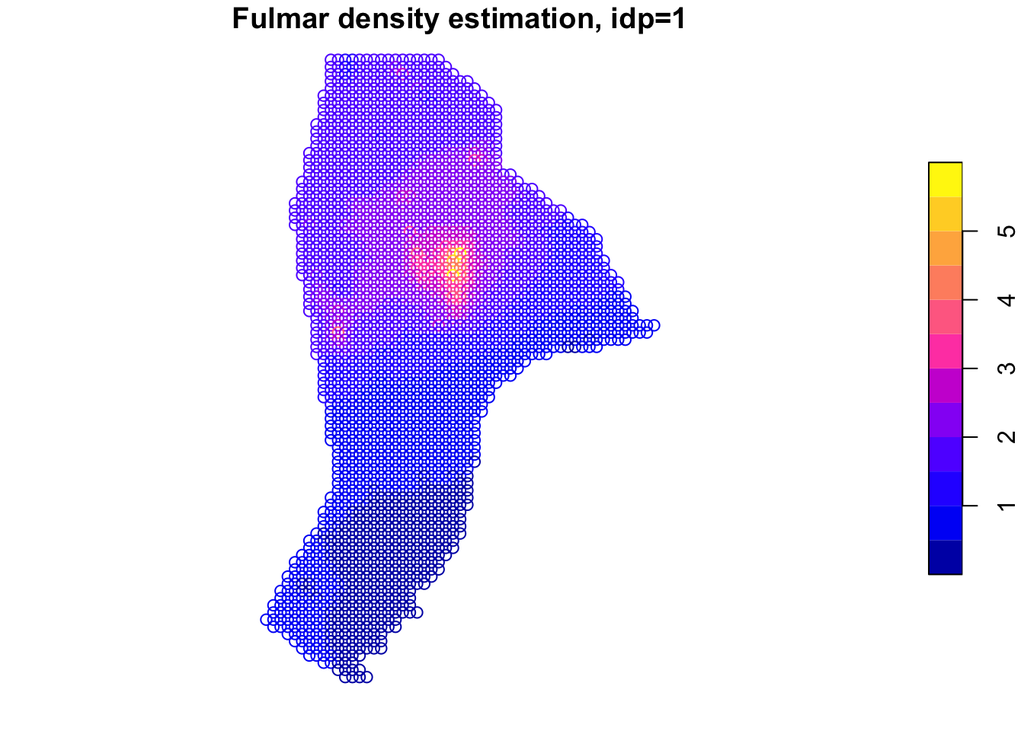

```r
plot(fulmar_idw1["var1.pred"], main="Fulmar density estimation, idp=1")
```

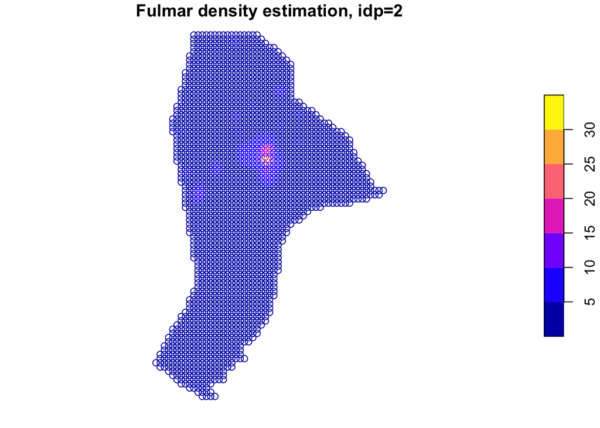

```r
plot(fulmar_idw2["var1.pred"], main="Fulmar density estimation, idp=2")
```

Fancy plots:

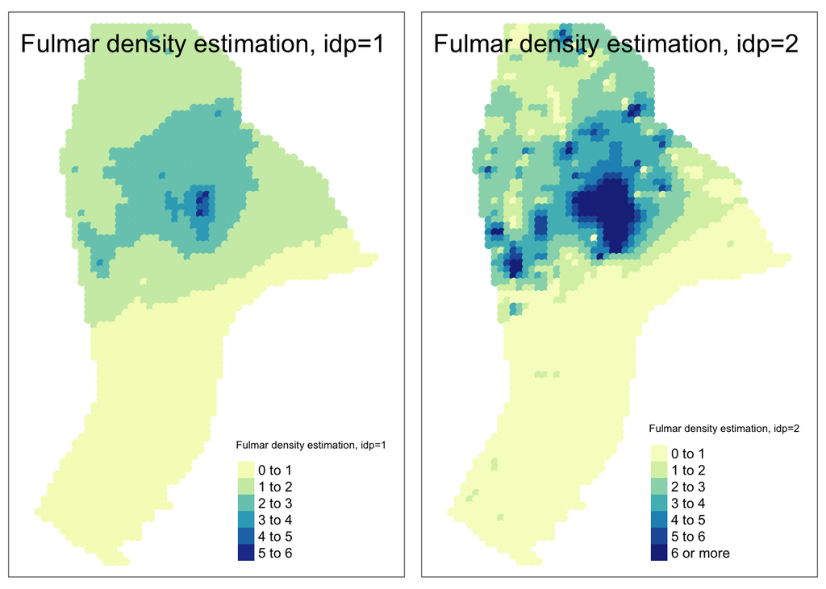

```r
fulmar_buff1 = st_buffer(fulmar_idw1, dist=3500) # you need to trial and error the ideal distance
fulmar_buff2 = st_buffer(fulmar_idw2, dist=3500)
idw_map1 = tm_shape(fulmar_buff1) + tm_fill(col="var1.pred", palette="YlGnBu", title="Fulmar density estimation, idp=1") + tm_layout(title="Fulmar density estimation, idp=1")
idw_map2 = tm_shape(fulmar_buff2) + tm_fill(col="var1.pred", breaks=c(0,1,2,3,4,5,6,Inf), palette="YlGnBu", title="Fulmar density estimation, idp=2") + tm_layout(title="Fulmar density estimation, idp=2")
tmap_arrange(idw_map1, idw_map2)
```